# Lecture_38

Zheyuan Wu

2023-04-24

In R: `pf(x, v_1, v_2)` gives $P(F_{v_1,v_2}\leq x)$.

Example: What is the conclusion for the sound example? Use $\alpha = 0.05$.

Summary:

- We can summarize our calculations in an ANOVA table.
- Some final notation:

$$SST = SSTr + SSE\\
DF_{SST} = DF_{SST r} + DF_{SSE} = N − 1$$

- $SST$ is called the total sum of squares. ($SSTr$ is the variability between groups, the $SSE$ is variability within group)
- The ANOVA table partitions the total sum of squares into two parts: the error and the treatment.

| Source of Variation | Sum of Squares | Degrees of Freedom | Mean Square | F | p-value |
| --- | --- | --- | --- | --- | --- |
| Treatment | $SST_r$ | $k-1$ | $MSTr$ | $F_{H_0}$ |  |
| Error | $SSE$ | $N − k$ | $MSE$ |  |  |
| Total | $SST$ | $N − 1$ |  |  |  |

- $F_{H_0}$ is the test statistic in ANOVA test.

Example: The ANOVA table for the sound data is:

| Source of Variation | Sum of Squares | Degree of Freedom | Mean Square | F | p-value |
| --- | --- | --- | --- | --- | --- |
| Treatment | 41.73 | 2 | 20.87 | 5.96 | 0.0159 |
| Error | 42 | 15-3=12 | 3.5 |  |  |
| Total | 83.73 | 15-1=14 |  |  |  |

Assumptions:

1. The k samples are independent.
2. The variances of the k populations are equal.
3. The k populations are normally distributed (or$ n_i $ for all i)

#### In R:

```r
score <- c(7,4,6,8,9,5,5,3,1,4,2,4,6,1,2)
group <- c(rep(1,5), rep(2,5), rep(3,5))
group
```

```
##  [1] 1 1 1 1 1 2 2 2 2 2 3 3 3 3 3
```

```r
# aov is analysis of variance
fit <- aov(score ~ as.factor(group))
anova(fit)
```

```
## Analysis of Variance Table
##
## Response: score
##                  Df Sum Sq Mean Sq F value  Pr(>F)
## as.factor(group)  2 41.733  20.867  5.9619 0.01593 *
## Residuals        12 42.000   3.500
## ---
## Signif. codes:  0 '***' 0.001 '**' 0.01 '*' 0.05 '.' 0.1 ' ' 1
```

```r
# The as.factor is treatment, residuals is error
```

Example: Researchers recruited overweight subject’s and randomly assigned them to one of four popular diet plans: Atkins, Ornish, Weight Watchers, and Zone. Each subject’s weight loss was measured after one year.

| Diet | Sample Mean weight Loss (in pounds) | n |
| --- | --- | --- |
| Atkins | 3.92 | 21 |
| Ornish | 6.56 | 20 |
| Weight Watchers | 4.59 | 26 |
| Zone | 4.88 | 26 |

1. Fill in the empty cells of the ANOVA table.

| Source of Variation | Sum of Squares | Degrees of Freedom | Mean Square | F | p-value |
| --- | --- | --- | --- | --- | --- |
| Treatment | 78 | 4-1=3 | 78/3=26 | 0.539 |  |
| Error | 4294 | 93-4=89 | 4294/89=48.25 |  |  |
| Total | 4372 | 93-1=92 |  |  |  |

2. Tests whether the average weight losses for the four diets are different. Use $\alpha = 0.10$.

Let $\mu$ denote the average weight losses for the ith diet, $i=1,2,3,4$

$H_0:\mu_1=\mu_2=\mu_3=\mu_4$

$H_a:$ at lease one of them is different

$$F={26\over48.25}=0.539$$

the p-value is

```r
1-pf(0.539,3,89)
```

```
## [1] 0.6568001
```

We failed to reject $H_0$ because we don’t have sufficient evidence of a difference in average weight loss for four is different.

### Simple Linear Regression

Simple linear regression allows us to investigate the relationship between two variables Y and X.

- Y = the response, outcome, or dependent variable
- X = the explanatory, predictor, or independent variable

Goal: To describe how $E(Y | X = x)$ varies as a function of x.

Example: The data set heights.txt (on Canvas) contains the heights (in inches) of 1375 mother/daughter pairs.

```r
heights<-read.csv("./heights.txt",sep=" ")
head(heights)
```

```
##   Mheight Dheight
## 1    59.7    55.1
## 2    58.2    56.5
## 3    60.6    56.0
## 4    60.7    56.8
## 5    61.8    56.0
## 6    55.5    57.9
```

Recall: We already have some tools for looking at relationships between two variables.

1. Scatter plots

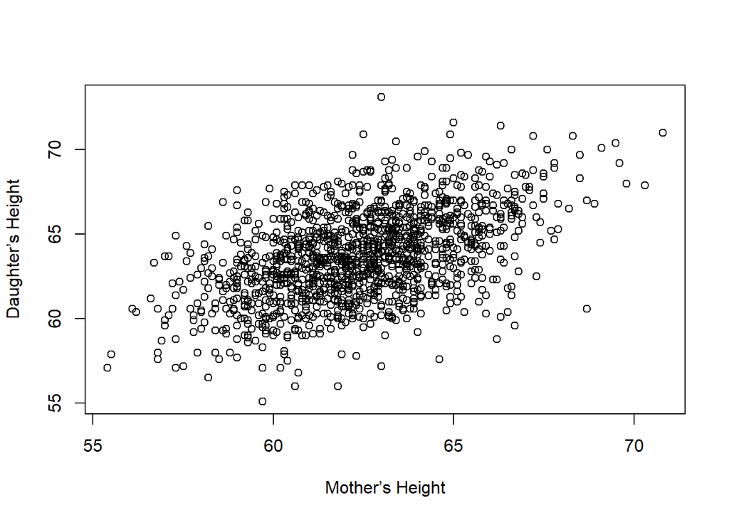

   ```r
   plot(heights$Mheight, heights$Dheight, xlab="Mother’s Height", ylab="Daughter’s Height")
   ```

2. Covariance =$ Cov(X, Y )$ and sample covariance = $S_{X,Y}$

   ```r
   cov(heights$Mheight, heights$Dheight)
   ```

   ```
   ## [1] 3.004806
   ```

3. Correlation = Corr(X, Y ) and sample correlation = rX,Y

   ```r
   cor(heights$Mheight, heights$Dheight)
   ```

   ```
   ## [1] 0.4907094
   ```

#### Regression Model

The simple linear regression model is

$$Y = \alpha_1 + \beta_1 X + \epsilon$$
The error variable ε:

1. has a N(0, σ2 ε ) distribution
2. $Cov(X, \epsilon) = 0$
3. $\sigma_\epsilon^2$ is the same for all values of x.

Results:

1. $E(Y | X = x) = \alpha_1 + \beta_1 x$

$$E(Y|X=x)=E(\alpha_1+\beta_1 x +\epsilon|x)=\alpha+\beta
E(X|x)+E(\epsilon|x)$$

$E(\epsilon|x)=0$

2. The distribution of $Y | X = x$ is $N(\alpha_1 + \beta_1 x, σ^2_\epsilon )$.

#### The Method of Least Squares

We will use least squares to estimate the parameters of the linear regression model. Let $(X_1, Y_1), . . . ,(X_n, Y_n)$ be a random bivariate sample from the population.

Make the distance of observed point and prediction line is as small as possible

$$SSE = \sum_{i=1}^n(y_i-\hat y_i)^2=\sum_{i=1}^n(y_i-(\hat
\alpha_1+\hat\beta_1x_i))^2=\sum_{i=1}^n \hat \epsilon_i^2$$

These vertical distances are the estimated errors and are called residuals:

$$\hat \epsilon _i=Y_i-\hat Y_i$$

Minimizing the SSE provides the estimates:

$$\hat \beta_1={S_{X,Y}\over S_X^2},\hat\alpha_1=\bar Y-\hat\beta_1\bar X$$

To ensure the fitted line passed the overall mean point $(\bar X,\bar Y)$

*derivative is required for computing these values by hand… (minimizing the value means the derivative is zero)*

We can also use the SSE to estimate $\sigma_\epsilon^2$:

$$S_\epsilon^2={SSE\over n-2}$$

$n-2$ is the df of residual.

We can obtain these estimates using R.

```r
model <- lm(Dheight~Mheight, data = heights)
model$coefficients
```

```
## (Intercept)     Mheight
##   29.917437    0.541747
```

```r
model$residuals
```

[output not shown]

[output cut: 405 more lines]

[output not shown]

```r
sum(model$residuals^2)/model$df.residual
```

```
## [1] 5.136167
```

```r
# sum(model$residuals^2) is SSE, df.residual is n-2
```

Note: The least squares estimates are also the maximum likelihood estimates of the parameters.

Interpretation

- The estimated intercept, $\hat\alpha_1$, is the estimated average value of Y when X = 0.

Example: $\hat\alpha_1=29.917$

The estimated average height of women chose mothers heights are 0 inches is 29.917 inches.

- The estimated slope, $\hat \beta_1$, is the estimated change in the average of $Y | X = x$ for a one-unit increase in x.

Example: $\hat \beta_1=0.542$